# Sesión 1.2. Introducción a python

Ingeniería de Servicios

2023-2024

# 1 Introducción

En esta asignatura se utilizará el lenguaje de programación Python para la mayoría de las prácticas debido a la simplicidad de su sintaxis y a la gran variedad de bibliotecas que vienen incorporadas al lenguaje y que hacen posible el abordar los problemas planteados en estas prácticas desde diferentes niveles de abstracción.

En esta primera sesión se indica cómo instalar un entorno de desarrollo basado en Python, para que el alumno que lo desee pueda hacerlo también en su ordenador particular, y se introduce someramente su sintaxis y filosofía.

Ten en cuenta que esta asignatura usa Python3 en lugar de Python2, que se comporta de forma diferente en lo que respecta a la entrada/salida de cadenas, entre otras cosas[^1].

# 2 Instalación

> No necesitas instalarlo en la máquina de prácticas, pues ya viene. Esta sección explica cómo instalarlo en otras plataformas.

Dependiendo del sistema operativo en que se quiera trabajar, podemos encontrar:

- En OSX Python ya viene preinstalado, pero la versión que trae es la 2.7. No obstante, ya que en esta asignatura usaremos Python3, que no es sencillo de instalar en OSX, junto con otras herramientas y servidores propios del mundo linux, que tampoco serían sencillos de instalar en OSX, la mejor opción para un alumno que use este operativo es que utilice VirtualBox (versión para OSX) para crear e instalar una máquina virtual con Ubuntu Server, como se describe en otro guión de prácticas.
- En la mayoría de las distribuciones de Linux también viene preinstalado, o bien se instala con un simple `sudo apt-get install python`. En Ubuntu 16.04 LTS (tanto en la versión escritorio como la de servidor) se instala también python 3.5 de forma automática. Cuando tecleas `python` a secas la versión que se intenta cargar es la 2.7, que no viene preinstalada por lo que dará un error. Para usar la versión 3, que es la que necesitamos, hay que teclear `python3`.
- En Windows la alternativa típica suele ser descargar un instalador específico para Windows desde la [página de descarga de python](http://www.python.org/downloads/). Sin embargo este enfoque requiere tener permisos de administrador para posteriormente poder ejecutar dicho instalador. Por ello, otra alternativa popular es la instalación de una versión “portable”. Este tipo de versiones no requieren una instalación propiamente dicha, sino simplemente que sean copiadas a una carpeta cualquiera desde la cual se ejecutarán (funcionan también desde un lápiz usb), y ya que no modifican archivos de sistema no requieren permisos de administración.

El siguiente apartado explica cómo instalar una versión portable para windows, por si quieres hacerlo en tu casa para llevar siempre contigo (en un lápiz USB) un entorno python que pueda ser usado en cualquier ordenador Windows. No obstante, no necesitas hacer esto en los ordenadores de prácticas en los que ya está instalado. Además en esta asignatura haremos casi todas las prácticas en Linux, donde también viene preinstalado como ya se ha dicho.

## 2.1 Instalación de python portable en Windows

Lo que se describe en esta sección no es necesario para esta asignatura, pues Python ya está instalado en los ordenadores de prácticas. Es sólo por si quieres hacerlo en tu ordenador personal.

1. Ve a la [página de descarga](http://winpython.github.io/) y descarga la versión más reciente de WinPython **3.4**.x.x.
2. Obtendrás un fichero ejecutable (`.exe`) que es en realidad un archivo comprimido auto-extraíble. Al ejecutarlo te preguntará dónde quieres extraerlo en tu disco duro. Aunque podrías darle como destino un lápiz USB no se recomienda hacerlo en este punto pues la escritura en las memorias *flash* es muy lenta. Dale como destino una carpeta de tu disco duro, preferiblemente en el raíz de la primera unidad de disco (`C:\`).
3. Una vez se ha extraído al destino que has especificado, puedes copiar la carpeta resultante a cualquier otro disco, incluyendo un lápiz USB externo.

Con esta copia la instalación está completada. De ahora en adelante, a la carpeta en la que se ha copiado WinPython la llamaremos `_WinPython_` en este documento. En tu caso el nombre real de la carpeta puede ser por ejemplo `C:\WinPython 3.4.4.3\`, de modo que cuando más adelante en el documento nos refiramos a la carpeta `_WinPython_\App`, se trataría en tu caso de la carpeta `C:\WinPython 3.4.4.3\App`.

## 2.2 Probando Python

Python es un lenguaje interpretado. Esto quiere decir que va leyendo una a una las órdenes que tú le des (bien sea directamente en una ventana del intérprete o bien en un fichero de texto en el que has escrito previamente el programa), y las va ejecutando. Si alguna de las líneas no puede ejecutarse debido a un error, la ejecución se abortará en ese punto.

Por tanto hay dos formas de probar python:

1. Abriendo el intérprete sin especificarle ningún archivo a ejecutar, y tecleando directamente en el intérprete las órdenes que queremos que ejecute. Este método es rápido para hacer pequeños experimentos, pero tiene el inconveniente de que lo que hayamos escrito se pierde al abandonar el intérprete.
2. Escribiendo previamente en un archivo las órdenes que componen nuestro programa y después ejecutando el intérprete pasándole como argumento el nombre del fichero que hemos escrito. Es costumbre poner a estos ficheros extensión `.py`.

Aún hay una tercera que consiste en escribir el programa en un fichero `.py` y pasárselo como argumento al intérprete, pero con una opción que hace que cuando termine de ejecutar ese programa, en lugar de finalizar, el intérprete se quede a la espera de nuevas órdenes, que recibiría en este caso directamente desde el teclado. Esta tercera opción es como una mezcla de las dos anteriores, ya que nos permite escribir en un fichero definiciones de funciones y variables con las que después podremos experimentar interactivamente en la ventana del intérprete.

Vamos a probar ambas formas como sigue:

### 2.2.1 Probar el intérprete interactivo

El intérprete se llama `python3`. En sistemas Unix basta abrir una terminal y teclear `python3` para entrar en ese intérprete y poder comenzar a darle comandos. En sistemas Windows, si python ha sido instalado desde su instalador oficial, éste habrá modificado el `PATH` del sistema de modo que al abrir una interfaz de comandos de Windows (`cmd`) también será posible teclear `python3` directamente desde esa ventana.

En cambio, ya que hemos instalado la versión portable de python y ésta no modifica nada en el sistema, el `PATH` no estará actualizado con la ruta hacia la carpeta donde haya sido instalado, y tendremos que especificar dicha ruta “a mano” al lanzar el intérprete desde una terminal. Haz lo siguiente:

1. Abre una interfaz de comandos (Ejecutar → `cmd`)
2. En ella escribe: `_WinPython_\App\python.exe`. Obtendrás un resultado como el siguiente:

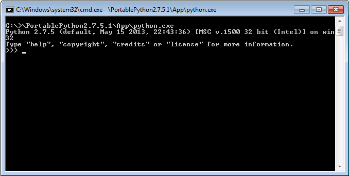

3. Prueba a escribir cualquier expresión matemática entre números (el operador de exponenciación es `**`) y verás el resultado. En modo intérprete interactivo, cada vez que python evalúa una expresión muestra en pantalla el resultado, sin que sea necesario hacer ningún `print()`

### 2.2.2 Escribiendo el programa

Abre un editor de texto cualquiera y escribe un fichero llamado `prueba.py` con el siguiente contenido:

```python
nombre = input("Como te llamas: ")
print("Hola", nombre)
```

La función `input()` lee del teclado la respuesta del usuario, hasta que este pulse retorno de carro, y devuelve la cadena tecleada (incluyendo el retorno de carro final)[^2]. Si se le pasa un argumento a esta función, lo imprimirá a modo de *prompt* antes de leer la respuesta. En el código anterior asignamos la cadena respuesta a la variable `nombre` para seguidamente mostrarla por pantalla con un `print()`[^3]. Cuando ejecutas un programa python desde un fichero, a diferencia del intérprete interactivo, no se muestran automáticamente los resultados tras cada línea, sino que es necesario hacer un `print()` explícito cuando queramos ver algún resultado.

En la ventana de la interfaz de comandos usa `cd` (cambiar de directorio) hasta situarte en la carpeta en la que hayas guardado `prueba.py`, y ejecuta el siguiente comando:

```bash
> _WinPython_\App\python.exe prueba.py
```

Deberías ver cómo python te pide el nombre para saludarte a continuación. Estas pruebas sirven para comprobar que el intérprete está instalado correctamente.

## 2.3 Instalación de un IDE

Aunque, como ves, todo lo que necesitas para escribir y probar programas en python es un editor de textos y una interfaz de comandos, resulta por lo general más cómodo el poder utilizar un editor específico para el lenguaje que te ofrezca coloreado sintáctico, autocompletado de identificadores, etc, y si además tiene integrado un mecanismo que permita ejecutar el intérprete python y mostrar los resultados en un panel del editor, ya no sería necesario ni abrir una interfaz de comandos para probar el código.

Existen multitud de IDEs específicos para python, y otros IDEs de propósito general famosos como Eclipse también pueden ser usados con python. Incluso Visual Studio tiene un *plugin* que permite [trabajar con Python](https://www.visualstudio.com/es-es/features/python-vs.aspx), creando un entorno muy amigable con auto-completado, documentación on-line, etc.

Cuando trabajes con python en la máquina virtual Ubuntu, no podrás usar ninguno de estos IDEs, puesto que la versión Server que usamos no tiene display gráfico. En este caso el “ide” será un editor de texto cualquiera (por ejemplo `vim`) en el que escribirás el código, y la línea de comandos desde la que lo ejecutarás.